# Practical Machine Learning Homework

datatrainR

6 Dezember 2017

## Executive Summary

Working with the Weight Lifting Exercises Dataset from Velloso et al. (2013), we want to use the power of machine learning with regards to classification to find the best model to predict whether weight lifting exercises were correctly conducted or not. Among a barrage of classification algorithms, the random forest method came out as the most precise predictor in our training data set and hence this is the one we apply to the test dataset provided.

## Setup

Data is downloaded directly from the web. Alongside the workhorse package **caret**, we also use **randomForest** and **rattle** (for plotting).

```r
##Downloading data
setwd("E:/Lukas/Coursera/Data Specialization/machine_learning")
add_training <- "https://d396qusza40orc.cloudfront.net/predmachlearn/pml-training.csv"
add_test <- "https://d396qusza40orc.cloudfront.net/predmachlearn/pml-testing.csv"

download.file(add_training, destfile = "data_training.csv", method = "auto")
download.file(add_test, destfile = "data_test.csv", method = "auto")

training_data <- read.csv("data_training.csv", sep = ",", na.strings=c("NA","#DIV/0!", ""))
test_data <- read.csv("data_test.csv", sep = ",", na.strings=c("NA","#DIV/0!", ""))

##Packages
library(caret)
library(randomForest)
library(RANN)
library(rattle)
```

## Pre-Cleaning

Before throwing everything into the machine learning grinders, we take a close look at our datasets. The *sapply* call reveals a large number of missing values (sometimes almost all observations are missing). We find that these are distributional informations for every measurement set which are only entered for one observation per measurement. While they do contain measurement accuracy, they wont help for future one-off measurements, so we drop them as well as all information on the recording time.

```r
sapply(training_data, function(x) sum(is.na(x)))
NA_cols <- is.na(head(training_data,1))
drop_cols <- names(training_data[,is.na(head(training_data,1))])
drop_cols <- c(drop_cols,"X","user_name","raw_timestamp_part_1","raw_timestamp_part_2","cvtd_timestamp","new_window","num_window")

training_data <- training_data[,!(names(training_data) %in% drop_cols)]
test_data <- test_data[,!(names(test_data) %in% drop_cols)]
```

## Training the models

Since we need to be able to compare the different models we are running, we re-partition the training set into two parts, keeping one aside for validation of the respective models.

```r
inTrain <- createDataPartition(training_data$classe, p = 3/4)[[1]]
train <- training_data[inTrain, ]
test <- training_data[-inTrain, ]
```

Then, using **caret**, we fit a support vector machine, a standard decision tree model, as well as two random forest models (one with normalized input data). As our outcome variable has 5 dimensions (oucome A being correct execution of the exercise and the others being different types of mistakes), we expect the nonlinear approaches to perform best.

```r
##Decision Tree model
dectree_model1 <- train(classe~.,method="rpart",data=train)
##Random Forest Model
rf_model1 <- train(classe~.,method="rf",data=train,verbose=TRUE)
rf_model2 <- train(classe~.,method="rf",preProcess = c("center", "scale"),data=train,verbose=TRUE)
##Support Vector Model
svm_model1 <- train(classe~.,method="svmLinear",preProcess = c("center", "scale"),data=train)
save.image("E:/Lukas/Coursera/Data Specialization/machine_learning/workspace_training.RData")
```

Instead of actually running this, which might take ages, we load the results from a local drive

```r
load("E:/Lukas/Coursera/Data Specialization/machine_learning/workspace_training.RData")
```

Visualizing the output we find that the less computationally intensive decision tree model identified roll_belt, pitch_forarm, magnet_dumbbell_y, as well as roll_forearm as the best classifiers. These variables also appear among the ones with highest importance in the two random forest models with the most important classifier being roll_belt.

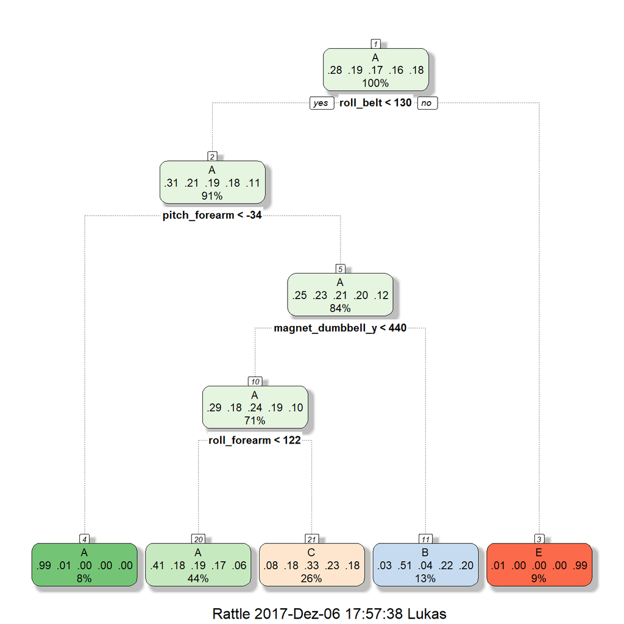

```r
##Decision Tree model
fancyRpartPlot(dectree_model1$finalModel)
```

```r
##Random Forest Model
varimport1 <- varImp(rf_model1)$importance
varimport2 <- varImp(rf_model2)$importance
importance_df <- data.frame(names_raw=row.names(varimport1), raw = varimport1$Overall,names_normalized= row.names(varimport2),  normalized = varimport2$Overall)
importance_df_ord <- importance_df[order(-importance_df$normalized),][1:10,]
row.names(importance_df_ord) <- NULL
print(importance_df_ord)
```

```
##            names_raw       raw  names_normalized normalized
## 1          roll_belt 100.00000         roll_belt  100.00000
## 2           yaw_belt  52.16534          yaw_belt   77.45413
## 3  magnet_dumbbell_z  42.65362 magnet_dumbbell_z   72.52816
## 4  magnet_dumbbell_y  43.00135 magnet_dumbbell_y   64.56175
## 5      pitch_forearm  57.16171     pitch_forearm   59.80363
## 6         pitch_belt  41.62512        pitch_belt   58.98890
## 7  magnet_dumbbell_x  17.04390 magnet_dumbbell_x   53.42960
## 8       roll_forearm  41.34917      roll_forearm   50.42101
## 9   accel_dumbbell_y  23.46411  accel_dumbbell_y   46.02222
## 10     magnet_belt_z  14.58793     magnet_belt_z   44.46876
```

## Testing the models (cross-validation)

We apply these four models to the portion of the training set that we kept for model selection. Looking at the accuracy figures, the most complex models prevailed in this out-of sample test. We decide to take the sligthly more accurate **Random Forest 1** which uses raw data inputs.

```r
##Predictions
dectree_fit <- predict(dectree_model1, newdata = test, type = "raw")
rf_fit1 <- predict(rf_model1, newdata = test)
rf_fit2 <- predict(rf_model2, newdata = test)
svm_fit <- predict(svm_model1, newdata = test)

##Confusion matrices
#Decision Tree
confusionMatrix(dectree_fit,test$classe)$overall[1]
```

```
##  Accuracy
## 0.4912316
```

```r
#Raw Random Forest
confusionMatrix(rf_fit1,test$classe)$overall[1]
```

```
##  Accuracy
## 0.9955139
```

```r
#Normalized Random Forest
confusionMatrix(rf_fit2,test$classe)$overall[1]
```

```
##  Accuracy
## 0.9946982
```

```r
#Support Vector Machine
confusionMatrix(svm_fit,test$classe)$overall[1]
```

```
##  Accuracy
## 0.7797716
```

```r
##Winner Confusion Matrix
confusionMatrix(rf_fit1,test$classe)$table
```

```
##           Reference
## Prediction    A    B    C    D    E
##          A 1389    4    0    0    0
##          B    2  943    1    0    0
##          C    3    2  852    6    0
##          D    0    0    2  798    1
##          E    1    0    0    0  900
```

## Application to testing set

We confidently apply our chosen random forest method to predict the exercise quality of the data from the original test-set.

```r
predict(rf_model1, newdata = test_data)
```

```
##  [1] B A B A A E D B A A B C B A E E A B B B
## Levels: A B C D E
```